# Dead Gene Walking Results

2024-10-01

# Introduction

This notebook explores the overlap across the results obtained in the codeaton by our tool dead-gene-walking (DGW) against MicroBIGG-E.

Comparing DGW results against MicroBIGG-E:

- How many of the mutations DGW identifies are reported in MicroBIGG-E?
- How many genome accessions are present in MicroBIGG-E but do not report the mutations DGW found?

In addition:

- How prevalent are these mutations (i.e. group by lession_type and ref_gene in our output)

# Setup

## DGW results

DGW was ran as described [here](https://github.com/NCBI-Codeathons/amr-2024-team-prasad-feldgarden/tree/main/script), and the output for each taxon is shown in individual tables in the repository [here](https://github.com/NCBI-Codeathons/amr-2024-team-prasad-feldgarden/tree/main/results). These results are going to be compared against the MicroBIGG-E subset in the following section.

# Analysis of results

```r
# Install packges
library(DBI)
library(duckdb)
library(tidyverse)
library(dplyr)


# Import data
Kp_genomes <- read_tsv("data/randomset2/Kp_genomes.dgw")
Pa_genomes <- read_tsv("data/randomset2/Pa_genomes.dgw")
Ab_genomes <- read_tsv("data/randomset2/Ab_genomes.dgw")

microbigge <-  read_csv("results/microbigge_subset_randomset2.csv")

# Set up in-memory database for modeling
con <- dbConnect(duckdb(), dbdir = ":memory:")

# Register dfs into database
dbWriteTable(con, "kp_genomes", Kp_genomes)
dbWriteTable(con, "pa_genomes", Pa_genomes)
dbWriteTable(con, "ab_genomes", Ab_genomes)

dbWriteTable(con, "microbigge", microbigge)
```

Let’s first prepare the data to establish the comparisons/analysis.

```r
# Combine DGW results
dgw_combined <- dbGetQuery(con,
"SELECT
  *,
  md5(CONCAT(element_symbol, asm_acc, contig_acc, lesion)) AS mutation_id,
  'kp_genomes' AS cohort
FROM kp_genomes
UNION ALL
SELECT
  *,
  md5(CONCAT(element_symbol, asm_acc, contig_acc, lesion)) AS mutation_id,
  'pa_genomes' AS cohort
FROM pa_genomes
UNION ALL
SELECT
  *,
  md5(CONCAT(element_symbol, asm_acc, contig_acc, lesion)) AS mutation_id,
  'ab_genomes' AS cohort
FROM ab_genomes
")
dbWriteTable(con, "dgw_combined", dgw_combined, overwrite = TRUE)


# Is DGW reported in MicroBIGG-E?
dgw_in_mbigge <- dbGetQuery(con,
"SELECT
  dgw_combined.element_symbol,
  dgw_combined.asm_acc,
  dgw_combined.contig_acc,
  dgw_combined.lesion,
  dgw_combined.lesion_type,
  dgw_combined.cohort,
  dgw_combined.mutation_id,
  microbigge.element_symbol AS mb_element_symbol,
FROM dgw_combined
LEFT JOIN microbigge
ON dgw_combined.asm_acc = microbigge.asm_acc
AND LOWER(microbigge.element_symbol) LIKE CONCAT('%', LOWER(dgw_combined.element_symbol),'%')
")


#Find new mutations against MicroBIGG-E mutations
dgw_new <- dbGetQuery(con,
"WITH match AS (
SELECT DISTINCT
  mutation_id
FROM dgw_combined
WHERE LOWER(microbigge.element_symbol) LIKE CONCAT('%', LOWER(dgw_combined.element_symbol),'%')
)
SELECT DISTINCT
  dgw_combined.element_symbol,
  dgw_combined.asm_acc,
  dgw_combined.contig_acc,
  dgw_combined.lesion,
  dgw_combined.lesion_type,
  dgw_combined.cohort,
  STRING_AGG(microbigge.element_symbol) OVER (PARTITION BY dgw_combined.element_symbol, dgw_combined.asm_acc) AS mb_element_symbol,
FROM dgw_combined
LEFT JOIN microbigge
ON dgw_combined.asm_acc = microbigge.asm_acc
LEFT JOIN match
USING(mutation_id)
WHERE  match.mutation_id IS NULL
")
```

## How many of the mutations DGW identifies are reported in MicroBIGG-E?

```r
#Total output
dgw_output_combined <- dgw_combined %>%
  summarize(mutations = n_distinct(mutation_id, na.rm = TRUE),
            isolates = n_distinct(asm_acc, na.rm = TRUE),
            contigs = n_distinct(contig_acc, na.rm = TRUE))


# question1
q1 <- dgw_in_mbigge %>%
  filter(!is.na(mb_element_symbol)) %>%
  group_by(element_symbol) %>%
  summarize(mutations = n_distinct(mutation_id),
            isolates = n_distinct(asm_acc)) %>%
  arrange(desc(mutations))

# q1_inverse <- dgw_in_mbigge %>%
#   filter(is.na(mb_element_symbol)) %>%
#   group_by(element_symbol) %>%
#   summarize(mutations = n_distinct(mutation_id),
#             isolates = n_distinct(asm_acc))


print(q1)
```

```
## # A tibble: 8 × 3
##   element_symbol mutations isolates
##   <chr>              <int>    <int>
## 1 OprD                1240     1239
## 2 OmpK36                44       44
## 3 OmpK35                34       34
## 4 AmpD                  21       21
## 5 MexR                  12       12
## 6 CirA                   5        5
## 7 AdeS                   4        4
## 8 NalD                   1        1
```

## How many isolates are present in MicroBIGG-E but do not report the mutations DGW found?

DGW found 7016 new mutations in 6570 isolates.

*Klebsiella pneumoniae* OmpK35_N29fs was the most abundant, found in 1021 isolates. *NOTE: This mutation was also the most prevalent in `randomset1`*

*Klebsiella pneumoniae* OmpK35_G41fs was the second most abundant, found in 861 isolates.  
*NOTE: This mutation was also found in 10 sensitive isolates in the AST testet*

```r
# q2
q2 <- dgw_in_mbigge %>%
  filter(is.na(mb_element_symbol)) %>%
  mutate(taxon = case_when(grepl("kp", cohort) ~ "Klebsiella pneumoniae",
                           grepl("pa", cohort) ~ "Pseudomonas aeruginosa",
                           grepl("ab", cohort) ~ "Acinetobacter baumannii")) %>%
  group_by(taxon, element_symbol, lesion, lesion_type) %>%
  summarize(mutations = n_distinct(mutation_id),
            isolates = n_distinct(asm_acc)) %>%
  arrange(desc(mutations))

print(q2)
```

```
## # A tibble: 1,226 × 6
## # Groups:   taxon, element_symbol, lesion [1,226]
##    taxon                  element_symbol lesion lesion_type mutations isolates
##    <chr>                  <chr>          <chr>  <chr>           <int>    <int>
##  1 Klebsiella pneumoniae  OmpK35         N29fs  FRAMESHIFT       1022     1021
##  2 Klebsiella pneumoniae  OmpK35         G41fs  FRAMESHIFT        861      861
##  3 Klebsiella pneumoniae  OmpK35         R60fs  FRAMESHIFT        301      301
##  4 Pseudomonas aeruginosa OprD           S403fs FRAMESHIFT        138      138
##  5 Klebsiella pneumoniae  OmpK35         G208fs FRAMESHIFT        120      120
##  6 Pseudomonas aeruginosa NalD           S82fs  FRAMESHIFT        111      111
##  7 Klebsiella pneumoniae  OmpK35         L63fs  FRAMESHIFT         98       98
##  8 Pseudomonas aeruginosa NalD           Q133fs FRAMESHIFT         98       98
##  9 Pseudomonas aeruginosa OprD           A15fs  FRAMESHIFT         96       96
## 10 Klebsiella pneumoniae  OmpK35         D108fs FRAMESHIFT         91       91
## # ℹ 1,216 more rows
```

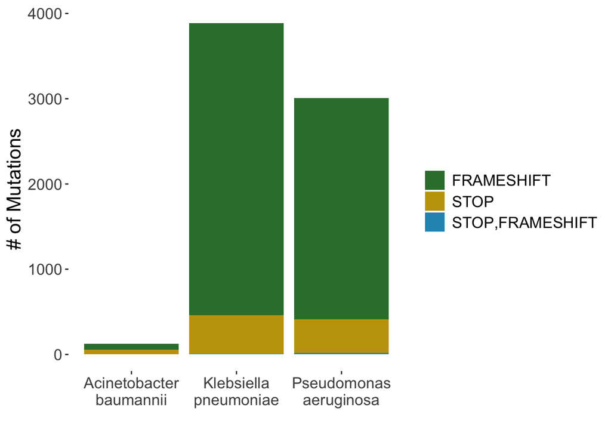

```r
# proportion of new mutations
q2 %>%
  group_by(lesion_type, taxon) %>%
  summarize(mutations = sum(mutations)) %>%
  ggplot(., aes(fill=lesion_type, y=mutations, x=taxon)) +
    geom_bar(position="stack", stat="identity") +
    scale_fill_manual(name="",values=c('#347d38', '#c4a208', '#2596be')) +
    theme(
      panel.grid.major = element_blank(),
      panel.grid.minor = element_blank(),
      panel.border = element_blank(),
      panel.background = element_blank(),
      text = element_text(size = 16)) +
    ylab("# of Mutations") + xlab("") +
    scale_x_discrete(labels = function(x) stringr::str_wrap(x, width = 20))
```

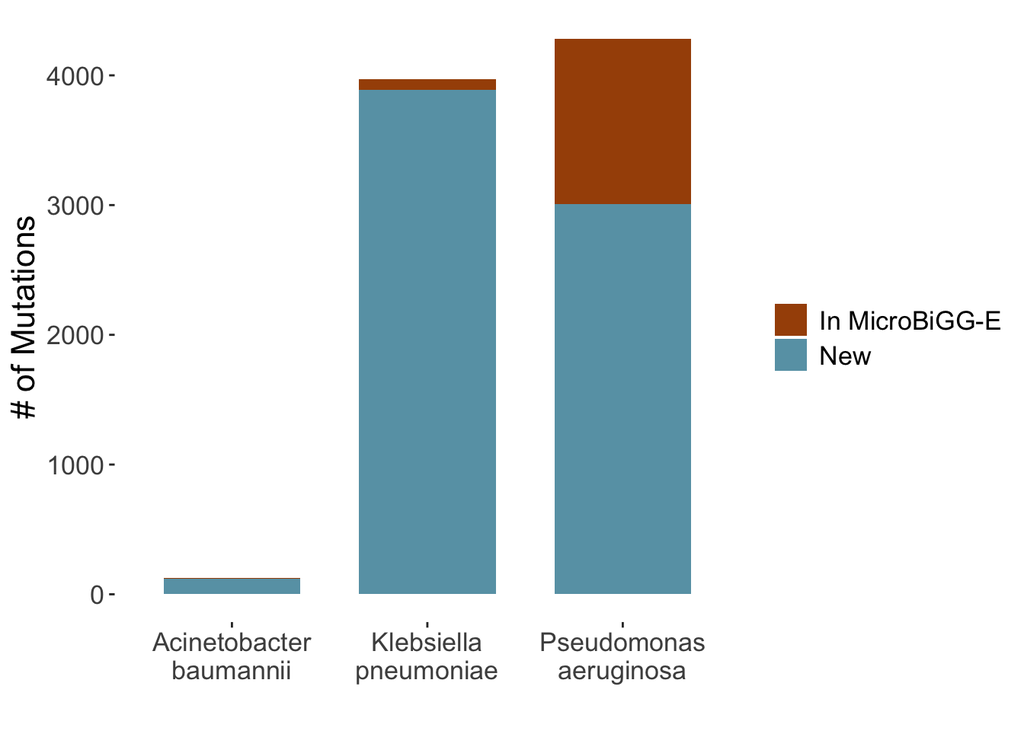

```r
# q3
q3 <- dgw_combined %>%
  mutate(taxon = case_when(grepl("kp", cohort) ~ "Klebsiella pneumoniae",
                           grepl("pa", cohort) ~ "Pseudomonas aeruginosa",
                           grepl("ab", cohort) ~ "Acinetobacter baumannii")) %>%
  group_by(taxon, lesion) %>%
  summarize(mutations = n_distinct(mutation_id),
            isolates = n_distinct(asm_acc))


# Split of DGW mutations in MicroBIGG-E vs New
dgw_in_mbigge %>%
  mutate(split = case_when(is.na(mb_element_symbol) ~ "New",
                          !is.na(mb_element_symbol) ~ "In MicroBiGG-E"),
         taxon = case_when(grepl("kp", cohort) ~ "Klebsiella pneumoniae",
                           grepl("pa", cohort) ~ "Pseudomonas aeruginosa",
                           grepl("ab", cohort) ~ "Acinetobacter baumannii")) %>%
  group_by(split, taxon) %>%
  summarize(mutations = n_distinct(mutation_id),
            isolates = n_distinct(asm_acc)) %>%
  ggplot(., aes(fill=split, y=mutations, x=taxon)) +
    geom_bar(position="stack", stat="identity", width=0.7) +
    scale_fill_manual(name="",values=c('#a65005', '#68a1b3')) +
    theme(
      panel.grid.major = element_blank(),
      panel.grid.minor = element_blank(),
      panel.border = element_blank(),
      panel.background = element_blank(),
      text = element_text(size = 16)) +
    ylab("# of Mutations") + xlab("") +
    scale_x_discrete(labels = function(x) stringr::str_wrap(x, width = 20))
```

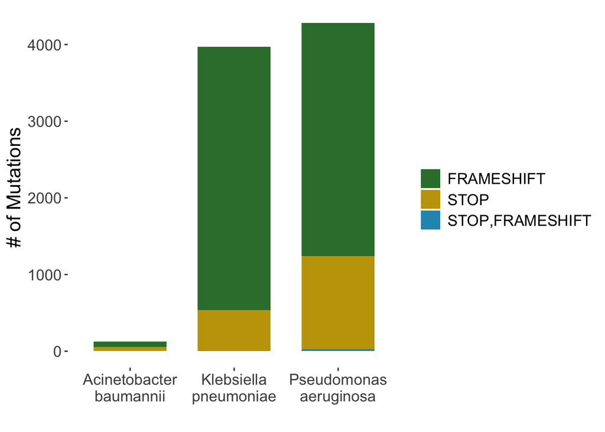

```r
# q3.2
q3_2 <- dgw_combined %>%
  group_by(lesion_type) %>%
  summarize(mutations = n_distinct(mutation_id),
            isolates = n_distinct(asm_acc))

dgw_combined %>%
  mutate(taxon = case_when(grepl("kp", cohort) ~ "Klebsiella pneumoniae",
                           grepl("pa", cohort) ~ "Pseudomonas aeruginosa",
                           grepl("ab", cohort) ~ "Acinetobacter baumannii")) %>%
  group_by(lesion_type, taxon) %>%
  summarize(mutations = n_distinct(mutation_id),
            isolates = n_distinct(asm_acc)) %>%
  ggplot(., aes(fill=lesion_type, y=mutations, x=taxon)) +
    geom_bar(position="stack", stat="identity", width=0.7) +
    scale_fill_manual(name="",values=c('#347d38', '#c4a208', '#2596be')) +
    theme(
      panel.grid.major = element_blank(),
      panel.grid.minor = element_blank(),
      panel.border = element_blank(),
      panel.background = element_blank(),
      text = element_text(size = 16)) +
    ylab("# of Mutations") + xlab("") +
    scale_x_discrete(labels = function(x) stringr::str_wrap(x, width = 20))
```

# How many mutations are found in each assembly?

```r
asm_mutations <- dbGetQuery(con,
"
SELECT
  microbigge.asm_acc,
  COUNT(DISTINCT(dgw_combined.mutation_id)) OVER (PARTITION BY microbigge.asm_acc) AS dgw_mutations_count,
  STRING_AGG(DISTINCT dgw_combined.element_symbol||dgw_combined.lesion) OVER (PARTITION BY microbigge.asm_acc) AS dgw_lesions,
  COUNT(DISTINCT(microbigge.element_symbol)) OVER (PARTITION BY microbigge.asm_acc) AS mb_mutations_count,
  STRING_AGG(DISTINCT microbigge.element_symbol) OVER (PARTITION BY microbigge.asm_acc ORDER BY microbigge.element_symbol) AS mb_element_symbol
FROM microbigge
LEFT JOIN dgw_combined
USING(asm_acc)
QUALIFY ROW_NUMBER() OVER (PARTITION BY microbigge.asm_acc ORDER BY microbigge.element_symbol DESC) = 1
")
```

# How abundant are the lesions DGW found?

```r
dgw_lesions <- dgw_combined %>%
  mutate(c_lesion = paste0(element_symbol,lesion)) %>%
  group_by(c_lesion) %>%
  summarize(mutations = n_distinct(mutation_id),
            isolates = n_distinct(asm_acc),
            frequency_perc = n_distinct(mutation_id)/n_distinct(dgw_combined$asm_acc)*100) %>%
  arrange(desc(mutations))

DT::datatable(dgw_lesions)
```

|  | c_lesion | mutations | isolates | frequency_perc |
| --- | --- | --- | --- | --- |
| 1 | OmpK35N29fs | 1022 | 1021 | 13.33333333333333 |
| 2 | OmpK35G41fs | 861 | 861 | 11.23287671232877 |
| 3 | OmpK35R60fs | 301 | 301 | 3.926940639269406 |
| 4 | OprDS401fs | 208 | 208 | 2.713633398564905 |
| 5 | OprDW277STOP | 176 | 176 | 2.296151337247228 |
| 6 | OprDS403fs | 138 | 138 | 1.800391389432485 |
| 7 | OmpK35G208fs | 120 | 120 | 1.565557729941291 |
| 8 | NalDS82fs | 111 | 111 | 1.448140900195695 |
| 9 | NalDQ133fs | 98 | 98 | 1.278538812785388 |
| 10 | OmpK35L63fs | 98 | 98 | 1.278538812785388 |

[output cut: 1328 more lines]

```r
dgw_mutation_counts <- dgw_combined %>%
  group_by(element_symbol) %>%
  summarize(mutations = n_distinct(mutation_id),
            isolates = n_distinct(asm_acc),
            frequency_perc = n_distinct(mutation_id)/n_distinct(dgw_combined$asm_acc)*100) %>%
  arrange(desc(mutations))

DT::datatable(dgw_mutation_counts)
```

|  | element_symbol | mutations | isolates | frequency_perc |
| --- | --- | --- | --- | --- |
| 1 | OmpK35 | 3586 | 3585 | 46.78408349641226 |
| 2 | OprD | 3129 | 3128 | 40.82191780821918 |
| 3 | NalD | 496 | 496 | 6.470971950424005 |
| 4 | AmpD | 338 | 338 | 4.409654272667971 |
| 5 | MexR | 318 | 318 | 4.148727984344423 |
| 6 | OmpK36 | 265 | 265 | 3.457273320287019 |
| 7 | AdeS | 127 | 127 | 1.656881930854534 |
| 8 | CirA | 118 | 118 | 1.539465101108937 |

# Summary